# DATA 624 | Predictive Analytics

Gabriella Martinez

2022-04-03

# Project 1

## Instructions

This project consists of 3 parts - two required and one bonus and is worth 15% of your grade. The project is due at 11:59 PM on Sunday Apr 3. I will accept late submissions with a penalty until the meetup after that when we review some projects.

## Packages

```r
library(readxl)
library(fpp3)
library(forecast)
library(ggplot2)
library(imputeTS)
library(readr)
```

## Part A – ATM Forecast

In part A, I want you to forecast how much cash is taken out of 4 different ATM machines for May 2010. The data is given in a single file. The variable ‘Cash’ is provided in hundreds of dollars, other than that it is straight forward. I am being somewhat ambiguous on purpose to make this have a little more business feeling.

- Explain and demonstrate your process, techniques used and not used, and your actual forecast.
- I am giving you data via an excel file, please provide your written report on your findings, visuals, discussion and your R code via an RPubs link along with the actual.rmd file
- Also please submit the forecast which you will put in an Excel readable file.

### Load Data

```r
#read in data and specify column types
atm_raw <- read_xlsx("ATM624Data.xlsx", col_types = c("date", "text", "numeric"))

#, col_types = c("date", "text", "numeric")

str(atm_raw)
```

```
## tibble [1,474 x 3] (S3: tbl_df/tbl/data.frame)
##  $ DATE: POSIXct[1:1474], format: "2009-05-01" "2009-05-01" ...
##  $ ATM : chr [1:1474] "ATM1" "ATM2" "ATM1" "ATM2" ...
##  $ Cash: num [1:1474] 96 107 82 89 85 90 90 55 99 79 ...
```

Based on the above, clean up is required before converting the tibble to a tsibble object for forecasting. Additionally, ATM4 shows values in terms of decimals even after accounting for the hundreds which suggests odd amounts including dollars and cents not typically dispensed by ATMs.

```r
#filter raw data for ATM4
atm_raw %>%
  filter(ATM == "ATM4")%>%
  head(10)
```

```
## # A tibble: 10 x 3
##    DATE                ATM    Cash
##    <dttm>              <chr> <dbl>
##  1 2009-05-01 00:00:00 ATM4  777.
##  2 2009-05-02 00:00:00 ATM4  524.
##  3 2009-05-03 00:00:00 ATM4  793.
##  4 2009-05-04 00:00:00 ATM4  908.
##  5 2009-05-05 00:00:00 ATM4   52.8
##  6 2009-05-06 00:00:00 ATM4   52.2
##  7 2009-05-07 00:00:00 ATM4   55.5
##  8 2009-05-08 00:00:00 ATM4  559.
##  9 2009-05-09 00:00:00 ATM4  904.
## 10 2009-05-10 00:00:00 ATM4  879.
```

### Exploratory Data Analysis

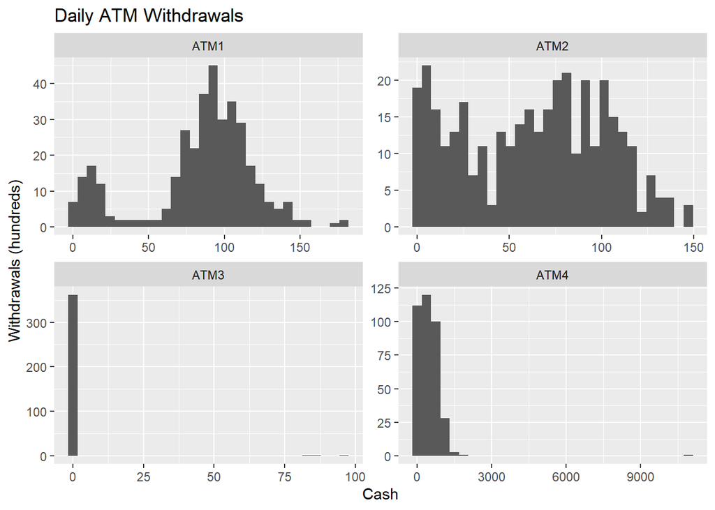

```r
#distro plot
atm_raw %>%
  filter(DATE < "2010-05-01", !is.na(ATM)) %>%
  ggplot(aes(x = Cash)) +
    geom_histogram(bins = 30) +
    facet_wrap(~ ATM, ncol = 2, scales = "free") +
    labs(title = "Daily ATM Withdrawals") +
    scale_y_continuous("Withdrawals (hundreds)")
```

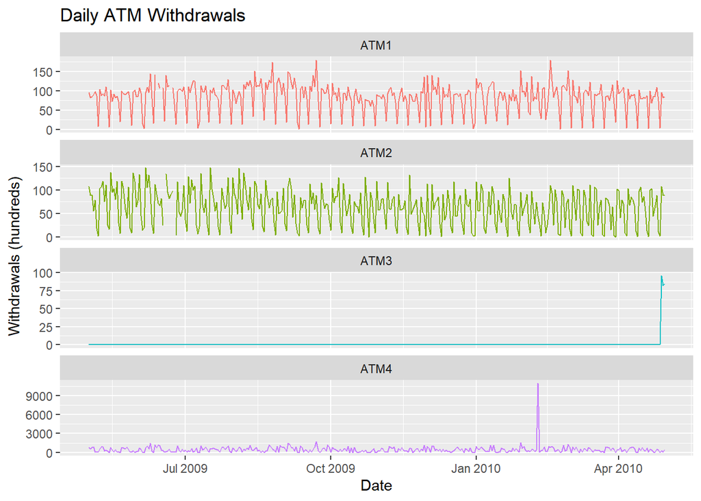

```r
#ts plot
atm_raw %>%
  filter(DATE < "2010-05-01", !is.na(ATM)) %>%
  ggplot(aes(x = DATE, y = Cash, col = ATM)) +
    geom_line(show.legend = FALSE) +
    facet_wrap(~ ATM, ncol = 1, scales = "free_y") +
    labs(title = "Daily ATM Withdrawals", x = "Date") +
    scale_y_continuous("Withdrawals (hundreds)")
```

```r
atm <- atm_raw %>%
  #lowercase column names
  rename(date=DATE, atm=ATM, cash=Cash) %>%
  #convert date column from POSIXct to date type , cash = cash*100
  mutate(date = as.Date(date)) %>%
  #convert from long to wide by expanding the atm column to get individual column for each atm
  pivot_wider(names_from=atm, values_from = cash) %>%
  #remove the NA column
  select(-"NA") %>%
  #filter out what we will be forecasting
  filter(date < "2010-05-01") %>%
  #convert to tsibble
  as_tsibble(index=date)

head(atm)
```

```
## # A tsibble: 6 x 5 [1D]
##   date        ATM1  ATM2  ATM3  ATM4
##   <date>     <dbl> <dbl> <dbl> <dbl>
## 1 2009-05-01    96   107     0 777.
## 2 2009-05-02    82    89     0 524.
## 3 2009-05-03    85    90     0 793.
## 4 2009-05-04    90    55     0 908.
## 5 2009-05-05    99    79     0  52.8
## 6 2009-05-06    88    19     0  52.2
```

#### NA value detection

Next we determine how many NAs we are dealing with and identify which ATMs have the NAs and on which dates. Using the below, both ATMs 1 and 2 seem to have all the NA values and all happen around the month of June.

```r
#how man NA values
apply(is.na(atm),2,sum)
```

```
## date ATM1 ATM2 ATM3 ATM4
##    0    3    2    0    0
```

```r
#what dates are NAs present
atm[!complete.cases(atm), ]
```

```
## # A tsibble: 5 x 5 [1D]
##   date        ATM1  ATM2  ATM3  ATM4
##   <date>     <dbl> <dbl> <dbl> <dbl>
## 1 2009-06-13    NA    91     0 746.
## 2 2009-06-16    NA    82     0 373.
## 3 2009-06-18    21    NA     0  92.5
## 4 2009-06-22    NA    90     0  80.6
## 5 2009-06-24    66    NA     0  90.6
```

```r
#unique(atm$ATM3)

#sum(is.na(atm_raw$ATM))
```

#### Summary statistics

```r
#summary stats
summary(atm)
```

```
##       date                 ATM1             ATM2             ATM3
##  Min.   :2009-05-01   Min.   :  1.00   Min.   :  0.00   Min.   : 0.0000
##  1st Qu.:2009-07-31   1st Qu.: 73.00   1st Qu.: 25.50   1st Qu.: 0.0000
##  Median :2009-10-30   Median : 91.00   Median : 67.00   Median : 0.0000
##  Mean   :2009-10-30   Mean   : 83.89   Mean   : 62.58   Mean   : 0.7206
##  3rd Qu.:2010-01-29   3rd Qu.:108.00   3rd Qu.: 93.00   3rd Qu.: 0.0000
##  Max.   :2010-04-30   Max.   :180.00   Max.   :147.00   Max.   :96.0000
##                       NA's   :3        NA's   :2
##       ATM4
##  Min.   :    1.563
##  1st Qu.:  124.334
##  Median :  403.839
##  Mean   :  474.043
##  3rd Qu.:  704.507
##  Max.   :10919.762
##
```

```r
atm$ATM4 <- round(atm$ATM4, 0)

head(atm)
```

```
## # A tsibble: 6 x 5 [1D]
##   date        ATM1  ATM2  ATM3  ATM4
##   <date>     <dbl> <dbl> <dbl> <dbl>
## 1 2009-05-01    96   107     0   777
## 2 2009-05-02    82    89     0   524
## 3 2009-05-03    85    90     0   793
## 4 2009-05-04    90    55     0   908
## 5 2009-05-05    99    79     0    53
## 6 2009-05-06    88    19     0    52
```

### Missing Values and Outliers

Using the `na.interp()` function from the forecast library, the missing values for ATM1 and ATM2 are generated through interpolation. “For seasonal series, a robust STL decomposition is first computed. Then a linear interpolation is applied to the seasonally adjusted data, and the seasonal component is added back.” [^1] The `na.interp()` was chosen over a mean method because the distributions for both ATM1 and ATM2 were skewed and the values are seasonal based on day of the week, so using a mean might not provide as accurate output as an interpolation method.

```r
#generate estimates for NAs and replace with new values

#ATM1
atm$ATM1 <- na.interp(atm$ATM1)

#ATM2
atm$ATM2 <-  na.interp(atm$ATM2)
```

Next, using the `tsoutliers()`[^2] function from the forecast library, we identify and replace the outlier skewing the data for ATM4.

```r
#ATM4

#identify the outlier index and generate a replacement
#tsoutliers(atm$ATM4)

#do the replacement
atm$ATM4[285] <- tsoutliers(atm$ATM4)$replacements
```

Given the slight skews detected for ATMs 1 and 2, we will also use `tsoutliers()` to detect any existing outliers and replace them accordingly. Neither ATM require outlier replacement.

```r
tsoutliers(atm$ATM1)
```

```
## $index
## integer(0)
##
## $replacements
## numeric(0)
```

```r
tsoutliers(atm$ATM2)
```

```
## $index
## integer(0)
##
## $replacements
## numeric(0)
```

Using the below we see there are no NA values remaining in ATMs 1 and 2, and the outlier for ATM4 has been taken care of. While the outlier for ATM4 has been resolved, there is still a high right skew on the data which is an indicator that a transformation may be required prior to modeling and forecasting.

```r
#verify how many NA values
apply(is.na(atm),2,sum)
```

```
## date ATM1 ATM2 ATM3 ATM4
##    0    0    0    0    0
```

```r
summary(atm)
```

```
##       date                 ATM1             ATM2             ATM3
##  Min.   :2009-05-01   Min.   :  1.00   Min.   :  0.00   Min.   : 0.0000
##  1st Qu.:2009-07-31   1st Qu.: 73.00   1st Qu.: 26.00   1st Qu.: 0.0000
##  Median :2009-10-30   Median : 91.00   Median : 67.00   Median : 0.0000
##  Mean   :2009-10-30   Mean   : 84.15   Mean   : 62.59   Mean   : 0.7206
##  3rd Qu.:2010-01-29   3rd Qu.:108.00   3rd Qu.: 93.00   3rd Qu.: 0.0000
##  Max.   :2010-04-30   Max.   :180.00   Max.   :147.00   Max.   :96.0000
##       ATM4
##  Min.   :   2.0
##  1st Qu.: 124.0
##  Median : 403.0
##  Mean   : 444.7
##  3rd Qu.: 704.0
##  Max.   :1712.0
```

### ATM 1 Forecast

Next, in order to uncover additional patterns noted in the series, an STL “Seasonal and Trend decomposition using Loess” decomposition is performed given the seasonality of the series. The parameter `trend(window = 7)` is set to 7 for the daily data, and the `season(window='periodic')` parameter force the seasonal component to be periodic across days of the week. Both trend and seasonal windows should be odd numbers; trend window is the number of consecutive observations to be used when estimating the trend-cycle; season window is the number of consecutive years to be used in estimating each value in the seasonal component.

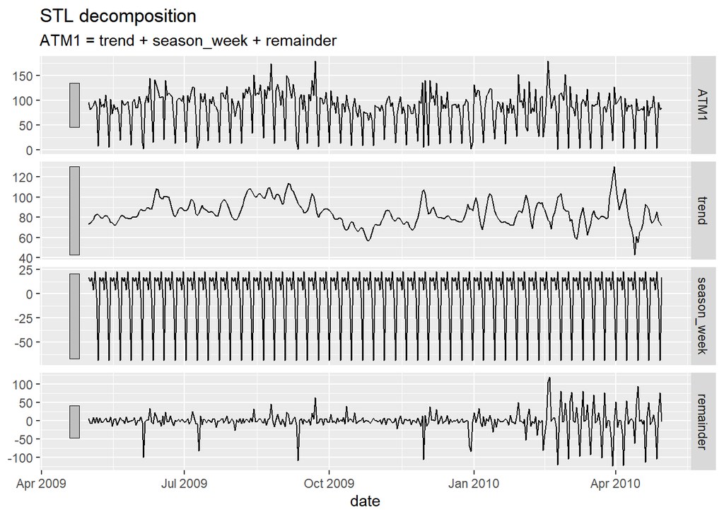

```r
ATM_1 <- atm %>%
  select(date, ATM1)

ATM_1 %>%
  model(
    STL(ATM1 ~ trend(window = 7) +
                   season(window = "periodic"),
    robust = TRUE)) %>%
  components() %>%
  autoplot()
```

The ACF plot below suggest lags at 2, 5, and 7 with 7 being the most significant lag. The ACF seems to be decreasing relatively slowly which could be an indicator that the data is non-stationary and could potentially benefit from differencing. Although the ACF is decreasing slowly, the $r_1$ value is not very large suggesting that the series might not be stationary. Additional checks are required.

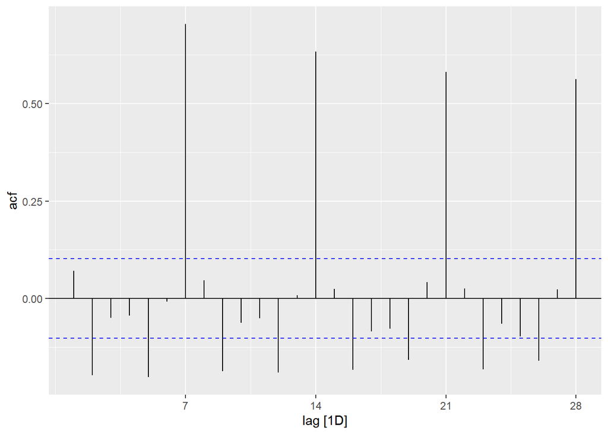

```r
ATM_1 %>%
  ACF(ATM1, lag_max = 28) %>%
  autoplot()
```

```r
  #gg_tsdisplay(plot_type='partial', lag_max = 28)
```

Following from above and in preparation for an ARIMA model, `ndiffs()` is used to determine if any differencing is required. Based on the output, there is no differencing required.

```r
ndiffs(ATM_1$ATM1)
```

```
## [1] 0
```

A KPSS test using `features(df$column, unitroot_kpss)` was considered to further evaluate if the series is stationary or not however a “major disadvantage for the KPSS test is that it has a high rate of Type I errors (it tends to reject the null hypothesis too often);” as such it has been omitted. [^3]

#### Model

Given the seasonal nature of the data, a reasonable approach is to include a seasonal naive method where last period’s sales are used for the next period’s forecast without predictions or adjusting the factors. Alternative models for this series are ETS and ARIMA models. An additional model that has been included is the `Auto ARIMA`, which is an automatically selected model by R with optimal values.

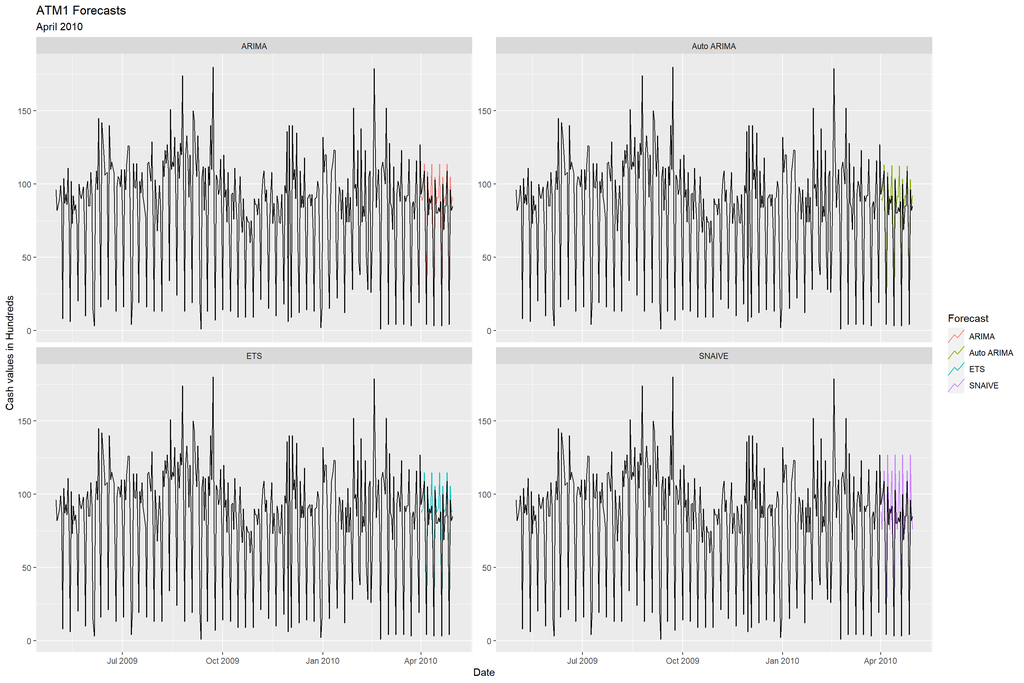

```r
#filter train data filter April data out to include it for eval later
train <- ATM_1 %>%
  filter(date < "2010-04-01")

#run seasonal related models
fit <- train %>%
  model(
    SNAIVE = SNAIVE(ATM1),
    ETS = ETS(ATM1),
    ARIMA = ARIMA(ATM1),
    `Auto ARIMA` = ARIMA(ATM1, stepwise = FALSE, approx = FALSE)
  )

#forecast_ATM1 April 2010
forecast_ATM1 <- fit %>%
  forecast(h = 30)

#plot
forecast_ATM1 %>%
  autoplot(ATM_1, level = NULL)+
  facet_wrap( ~ .model, scales = "free_y") +
  guides(colour = guide_legend(title = "Forecast"))+
  labs(title= "ATM1 Forecasts",
       subtitle = "April 2010") +
  xlab("Date") +
  ylab("Cash values in Hundreds")
```

#### Evaluation

Using the `accuracy()` function, we determine which model performed best based on their metrics. In review of the metrics, the ETS model has higher accuracy on the cross-validated performance measures for ATM1.

```r
#find RMSE and other metrics
accuracy(forecast_ATM1, ATM_1) %>%
  select(.model, RMSE:MAPE)
```

```
## # A tibble: 4 x 5
##   .model      RMSE   MAE   MPE  MAPE
##   <chr>      <dbl> <dbl> <dbl> <dbl>
## 1 ARIMA       12.4  9.71 -83.3  86.4
## 2 Auto ARIMA  12.9  9.75 -98.5 102.
## 3 ETS         11.6  9.11 -61.0  64.7
## 4 SNAIVE      16.0 13.5  -66.2  73.4
```

#### Generate Forecast

Next, the forecast for ATM1 is produced after obtaining the optimal model of the four generated above.

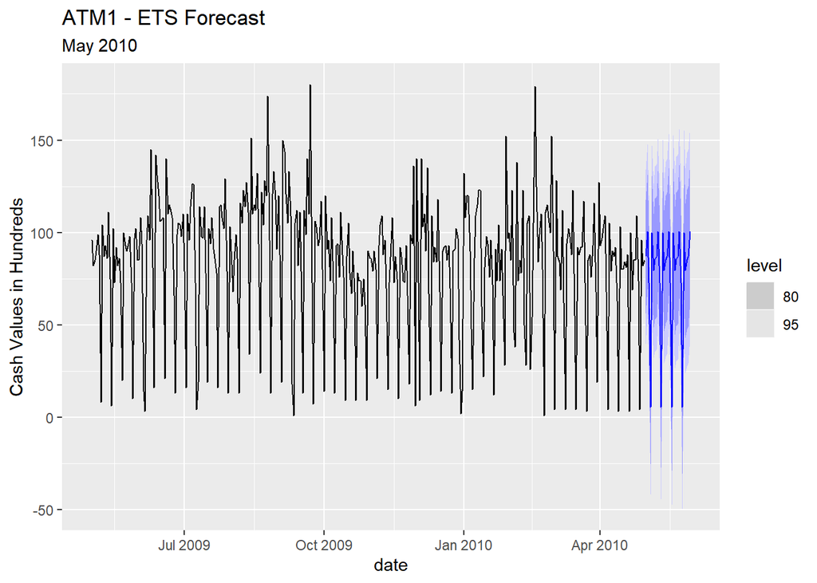

```r
#reproduce the mode using the original dataset
AMT1_ETS_fit <- ATM_1 %>%
  model(
    ETS = ETS(ATM1))

#generate the values
ATM1_EST_forecast <- AMT1_ETS_fit %>%
  forecast(h=30)

#plot
ATM1_EST_forecast %>%
  autoplot(ATM_1) +
  labs(title = "ATM1 - ETS Forecast",
       subtitle = "May 2010",
       y = "Cash Values in Hundreds")
```

```r
#convert to df and select only the columns needed
ATM1_forecast_values <- as.data.frame(ATM1_EST_forecast) %>%
  select(date, .mean)

#fix column names
colnames(ATM1_forecast_values) <- c('Date', 'Cash')

#back transform values
ATM1_forecast_values <- ATM1_forecast_values %>%
    mutate(Cash= round(Cash))

ATM1_forecast_values
```

```
##          Date Cash
## 1  2010-05-01   87
## 2  2010-05-02  101
## 3  2010-05-03   73
## 4  2010-05-04    6
## 5  2010-05-05  100
## 6  2010-05-06   79
## 7  2010-05-07   85
## 8  2010-05-08   87
## 9  2010-05-09  101
## 10 2010-05-10   73
## 11 2010-05-11    6
## 12 2010-05-12  100
## 13 2010-05-13   79
## 14 2010-05-14   85
```

[output cut: 16 more lines]

```r
#save to csv
write_excel_csv(ATM1_forecast_values, "ATM1_forecast.csv")
```

### ATM 2 Forecast

Similar to the process for ATM1, an STL “Seasonal and Trend decomposition using Loess” decomposition is performed to uncover any additional patterns in each component.

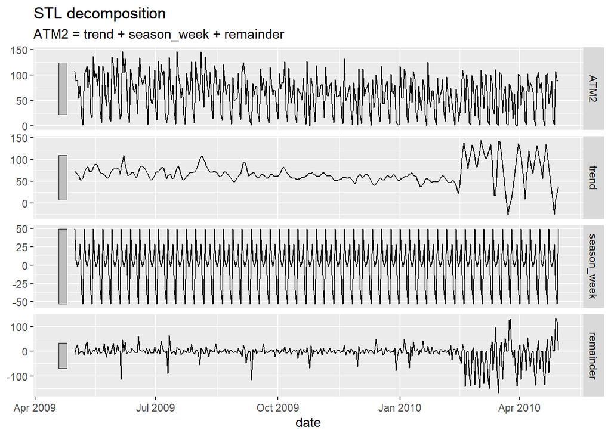

```r
ATM_2 <- atm %>%
  select(date, ATM2)

ATM_2 %>%
  model(
    STL(ATM2 ~ trend(window = 7) +
                   season(window = "periodic"),
    robust = TRUE)) %>%
  components() %>%
  autoplot()
```

The ACF plot below suggest lags at 2, 5, and 7 with 7 being the most significant lag. The ACF seems to be decreasing relatively slowly which could be an indicator that the data is non-stationary and could potentially benefit from differencing. Although the ACF is decreasing slowly, the $r_1$ value is not very large suggesting that the series might not be stationary. Additional checks are required.

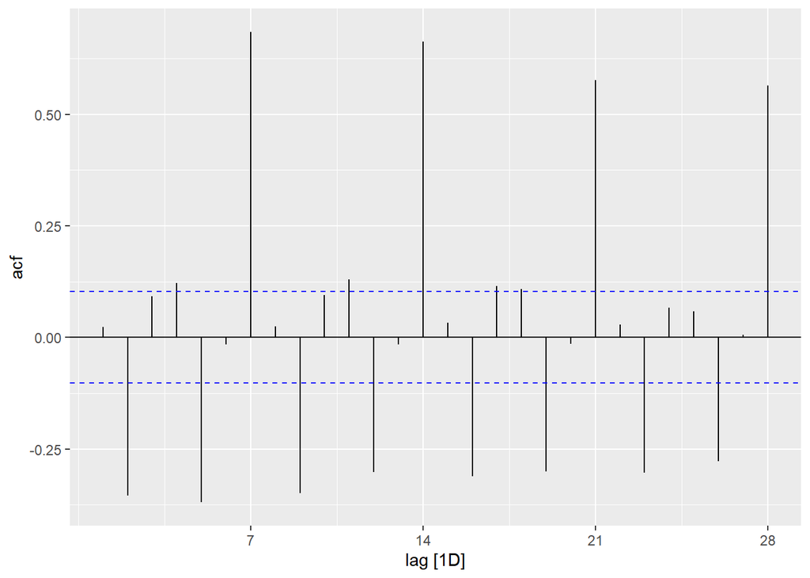

```r
ATM_2 %>%
  ACF(ATM2, lag_max = 28) %>%
  autoplot()
```

Following from above and in preparation for an ARIMA model, `ndiffs()` is used to determine if any differencing is required. Based on the output, differencing required.

```r
ndiffs(ATM_2$ATM2)
```

```
## [1] 1
```

#### Model

In the case of ATM2, 2 separate fits are generated. One fit with two models, SNAIVE and ETS, is generated using the non-differenced data. The other fit with three models, ETS, ARIMA, and Auto Arima, is generated using the differenced data.

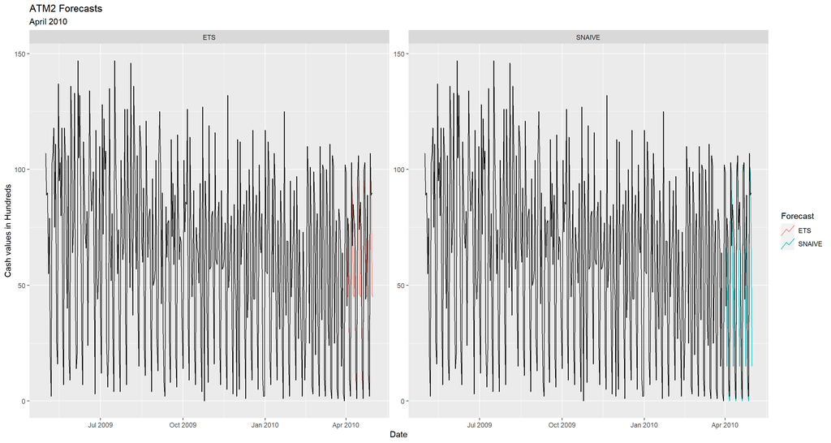

```r
#need to add differenced data
ATM_2 <- ATM_2 %>%
  mutate(diff_ATM2= difference(ATM2))

#filter train data filter April data out to include it for eval later
train <- ATM_2 %>%
  filter(date <= "2010-04-01")

#run seasonal related models without the differenced data
fit_1 <- train %>%
  model(
    SNAIVE = SNAIVE(ATM2),
    ETS = ETS(ATM2),
  )

#run models with differenced data
fit_2 <- train %>%
  slice(2:336) %>%
  model(
    ETS_diff = ETS(diff_ATM2),
    ARIMA = ARIMA(diff_ATM2),
   `Auto ARIMA` = ARIMA(diff_ATM2, stepwise = FALSE, approx = FALSE)
  )

#forecast_ATM2 April
forecast_ATM2_1 <- fit_1 %>%
  forecast(h = 30)

#forecast_ATM2 April
forecast_ATM2_2 <- fit_2 %>%
  forecast(h = 30)

#plot
forecast_ATM2_1 %>%
  autoplot(ATM_2, level = NULL)+
  facet_wrap( ~ .model, scales = "free_y") +
  guides(colour = guide_legend(title = "Forecast"))+
  labs(title= "ATM2 Forecasts",
       subtitle = "April 2010") +
  xlab("Date") +
  ylab("Cash values in Hundreds")
```

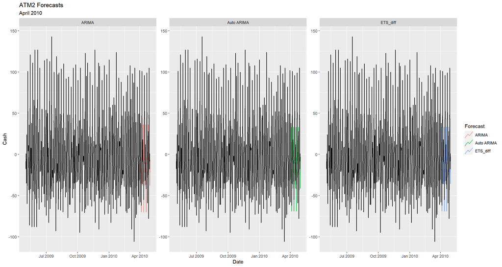

```r
#plot 2
forecast_ATM2_2 %>%
  autoplot(ATM_2, level = NULL)+
  facet_wrap( ~ .model, scales = "free_y") +
  guides(colour = guide_legend(title = "Forecast"))+
  labs(title= "ATM2 Forecasts",
       subtitle = "April 2010") +
  xlab("Date") +
  ylab("Cash")
```

#### Evaluate

Next the `accuracy()` function is run on both forecast objects to obtain the best fit based on the metrics. Of the five models run, the ETS model without the differenced data performs the best.

```r
#find RMSE and other metrics
accuracy(forecast_ATM2_1, ATM_2) %>%
  select(.model, RMSE:MAE)
```

```
## # A tibble: 2 x 3
##   .model  RMSE   MAE
##   <chr>  <dbl> <dbl>
## 1 ETS     19.1  13.7
## 2 SNAIVE  26.0  16.9
```

```r
accuracy(forecast_ATM2_2, ATM_2) %>%
  select(.model, RMSE:MAE)
```

```
## # A tibble: 3 x 3
##   .model      RMSE   MAE
##   <chr>      <dbl> <dbl>
## 1 ARIMA       26.2  19.5
## 2 Auto ARIMA  25.5  19.1
## 3 ETS_diff    25.0  19.1
```

#### Generate Forecast

Below the forcast is generated and plotted.

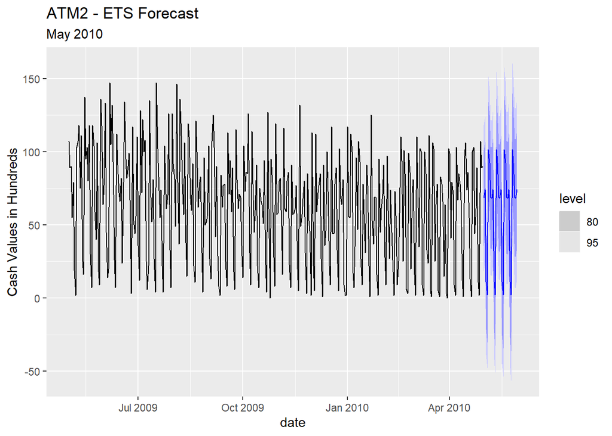

```r
#reproduce the mode using the original dataset
AMT2_ETS_fit <- ATM_2 %>%
  model(
    ETS = ETS(ATM2))

#generate the values
ATM2_EST_forecast <- AMT2_ETS_fit %>%
  forecast(h=30)

#plot
ATM2_EST_forecast %>%
  autoplot(ATM_2) +
  labs(title = "ATM2 - ETS Forecast",
       subtitle = "May 2010",
       y = "Cash Values in Hundreds")
```

```r
#convert to df and select only the columns needed
ATM2_forecast_values <- as.data.frame(ATM2_EST_forecast) %>%
  select(date, .mean)

#fix column names
colnames(ATM2_forecast_values) <- c('Date', 'Cash')

#round values for integer output
ATM2_forecast_values <- ATM2_forecast_values %>%
    mutate(Cash= round(Cash))

ATM2_forecast_values
```

```
##          Date Cash
## 1  2010-05-01   68
## 2  2010-05-02   74
## 3  2010-05-03   11
## 4  2010-05-04    2
## 5  2010-05-05  102
## 6  2010-05-06   92
## 7  2010-05-07   69
## 8  2010-05-08   68
## 9  2010-05-09   74
## 10 2010-05-10   11
## 11 2010-05-11    2
## 12 2010-05-12  102
## 13 2010-05-13   92
## 14 2010-05-14   69
```

[output cut: 16 more lines]

```r
#save to csv
write_excel_csv(ATM2_forecast_values, "ATM2_forecast.csv")
```

### ATM 4 Forecast

As seen below in the plot, ATM4 has the most variance of all ATMs modeled thus far; as such a mathematical transformation will be required.

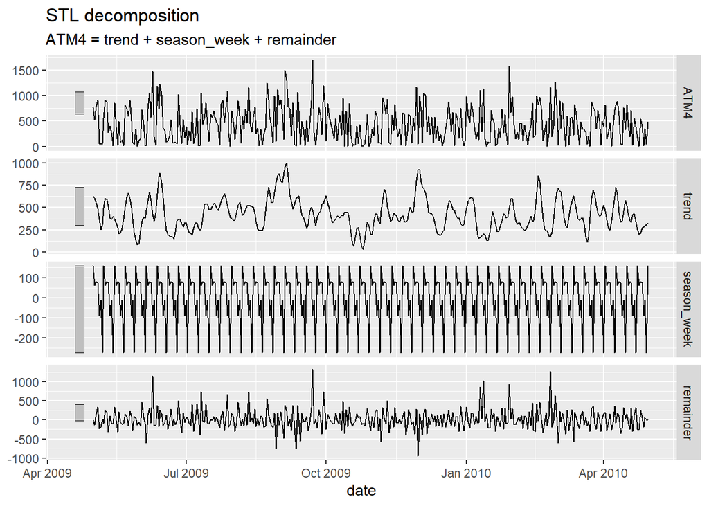

```r
ATM_4 <- atm %>%
  select(date, ATM4)

ATM_4 %>%
  model(
    STL(ATM4 ~ trend(window = 7) +
                   season(window = "periodic"),
    robust = TRUE)) %>%
  components() %>%
  autoplot()
```

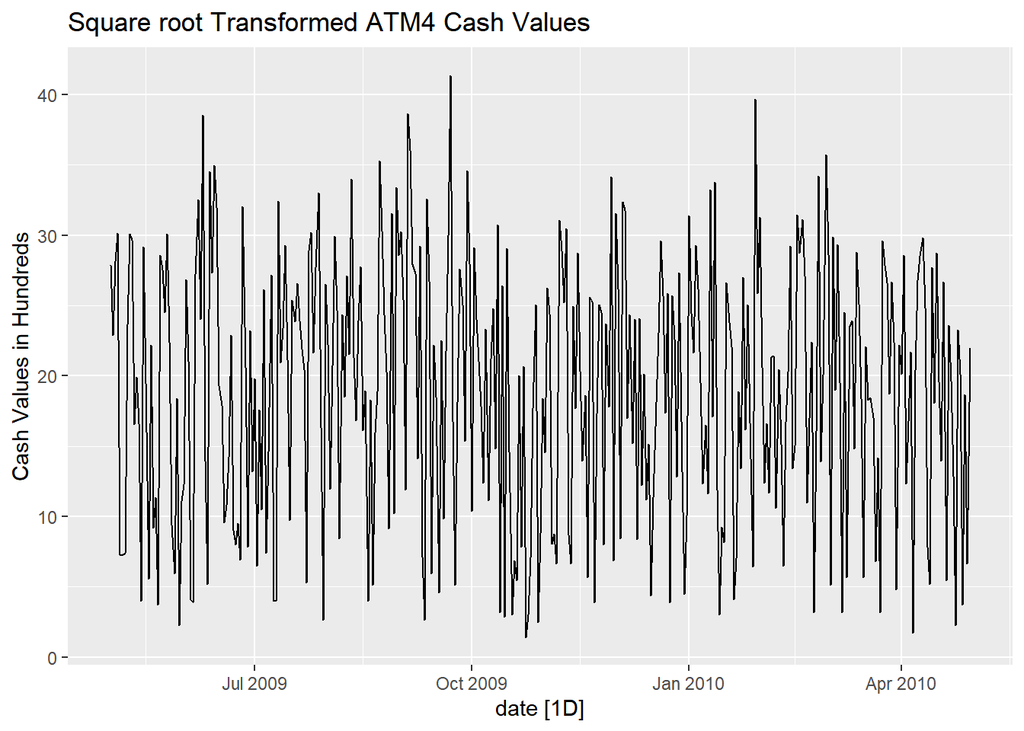

```r
#get lambda
lambda <- ATM_4 %>%
  features(ATM4, features = guerrero) %>%
  pull(lambda_guerrero)

#add new value- sqrt transform
ATM_4 <- ATM_4 %>%
    mutate(ATM4_sqrt= sqrt(ATM4))

#plot
ATM_4 %>%
  autoplot(ATM4_sqrt) +
  labs(y = "Cash Values in Hundreds",
       title ="Square root Transformed ATM4 Cash Values")
```

The summary of the Box-Cox transformed data suggests the skew identified above has decreased significantly in comparison to the earlier summary statistics run on the untransformed data. The transformed data is almost normal, with a slight left skew given the mean is left of the median by a relatively small amount.

```r
summary(ATM_4$ATM4_sqrt)
```

```
##    Min. 1st Qu.  Median    Mean 3rd Qu.    Max.
##   1.414  11.136  20.075  18.951  26.533  41.376
```

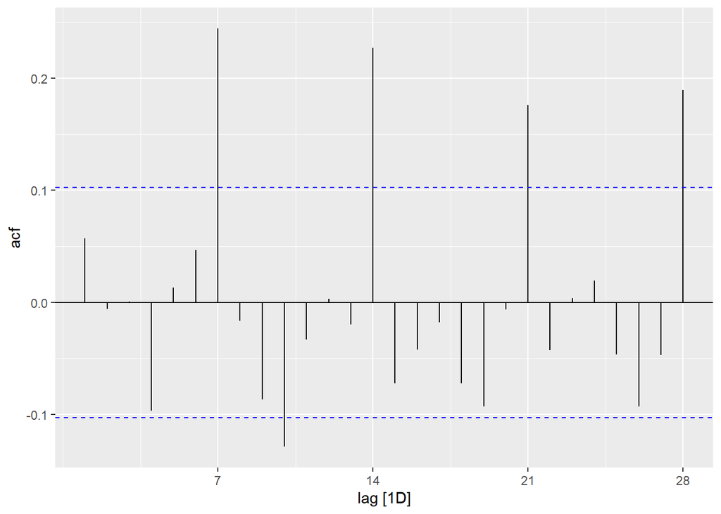

```r
ATM_4 %>%
  ACF(ATM4_sqrt, lag_max = 28) %>%
  autoplot()
```

Following from above and in preparation for an ARIMA model, `ndiffs()` is used to determine if any differencing is required. Based on the output, there is no differencing required.

```r
ndiffs(ATM_4$ATM4)
```

```
## [1] 0
```

```r
ndiffs(ATM_4$ATM4_sqrt)
```

```
## [1] 0
```

#### Model

Four different models are run for ATM4 SNAIVE, ETS, ARIMA, and an Auto ARIMA.

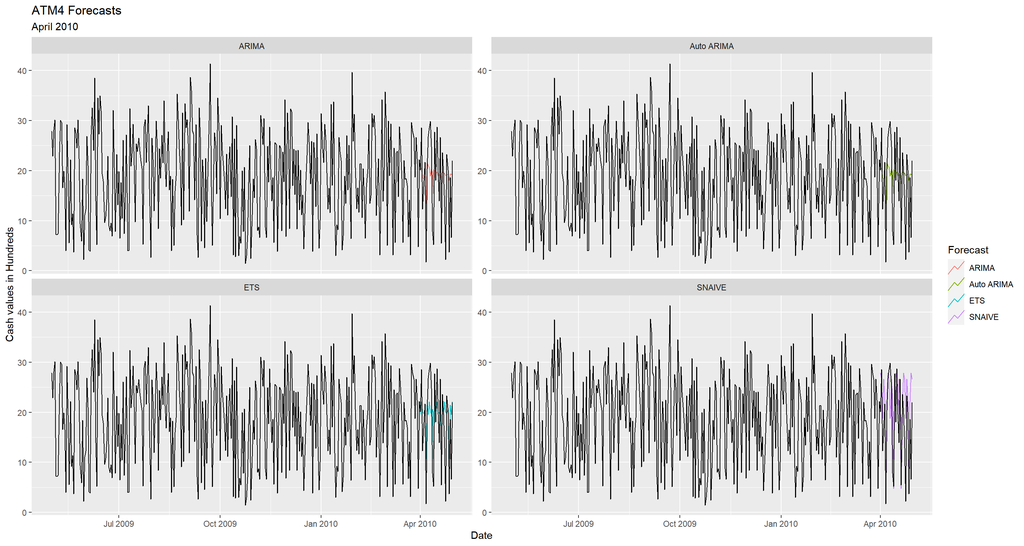

```r
#filter train data filter April data out to include it for eval later
train <- ATM_4 %>%
  filter(date < "2010-04-01")

#run seasonal related models
fit <- train %>%
  model(
    SNAIVE = SNAIVE(ATM4_sqrt),
    ETS = ETS(ATM4_sqrt),
    ARIMA = ARIMA(ATM4_sqrt),
    `Auto ARIMA` = ARIMA(ATM4_sqrt, stepwise = FALSE, approx = FALSE)
  )

#forecast_ATM1 April 2010
forecast_ATM4 <- fit %>%
  forecast(h = 30)

#plot
forecast_ATM4 %>%
  autoplot(ATM_4, level = NULL)+
  facet_wrap( ~ .model, scales = "free_y") +
  guides(colour = guide_legend(title = "Forecast"))+
  labs(title= "ATM4 Forecasts",
       subtitle = "April 2010") +
  xlab("Date") +
  ylab("Cash values in Hundreds")
```

#### Evaluation

```r
#find RMSE and other metrics
accuracy(forecast_ATM4, ATM_4) %>%
  select(.model, RMSE:MAE)
```

```
## # A tibble: 4 x 3
##   .model      RMSE   MAE
##   <chr>      <dbl> <dbl>
## 1 ARIMA       7.82  6.33
## 2 Auto ARIMA  7.82  6.33
## 3 ETS         6.91  5.47
## 4 SNAIVE      7.98  5.82
```

#### Generate Forecast

Finally the forecast for ATM4 is produced using the optimal model method uncovered in the previous step. In the case of ATM4, the best model is ETS. The final values are expressed using the square root transformed values and will be back transformed.

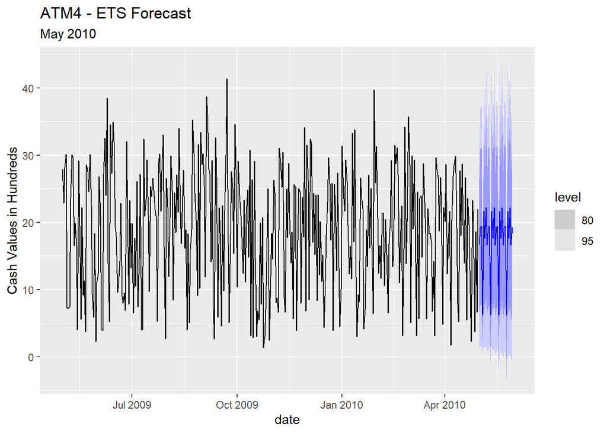

```r
#reproduce the mode using the original dataset
AMT4_SN_fit <- ATM_4 %>%
  model(ETS = ETS(ATM4_sqrt))

#generate the values
ATM4_SN_forecast <- AMT4_SN_fit %>%
  forecast(h=30)

#plot
ATM4_SN_forecast %>%
  autoplot(ATM_4) +
  labs(title = "ATM4 - ETS Forecast",
       subtitle = "May 2010",
       y = "Cash Values in Hundreds")
```

Lastly, the values of the forecast are saved into .CSV format for submission after being back transformed by squaring and rounding the values.

```r
#convert to df and select only the columns needed
ATM4_forecast_values <- as.data.frame(ATM4_SN_forecast) %>%
  select(date, .mean)

#fix column names
colnames(ATM4_forecast_values) <- c('Date', 'Cash')

#back transform values
ATM4_forecast_values <- ATM4_forecast_values %>%
    mutate(Cash= round(Cash**2))

ATM4_forecast_values
```

```
##          Date Cash
## 1  2010-05-01  277
## 2  2010-05-02  371
## 3  2010-05-03  378
## 4  2010-05-04   39
## 5  2010-05-05  469
## 6  2010-05-06  312
## 7  2010-05-07  493
## 8  2010-05-08  277
## 9  2010-05-09  371
## 10 2010-05-10  378
## 11 2010-05-11   39
## 12 2010-05-12  469
## 13 2010-05-13  312
## 14 2010-05-14  493
```

[output cut: 16 more lines]

```r
#save to csv
write_excel_csv(ATM4_forecast_values, "ATM4_forecast.csv")
```

## Part B – Forecasting Power

Part B consists of a simple dataset of residential power usage for January 1998 until December 2013. Your assignment is to model these data and a monthly forecast for 2014. The data is given in a single file. The variable ‘KWH’ is power consumption in Kilowatt hours, the rest is straight forward. Add this to your existing files above.

### Load Data

```r
power_raw <- read_xlsx("ResidentialCustomerForecastLoad-624.xlsx")

str(power_raw)
```

```
## tibble [192 x 3] (S3: tbl_df/tbl/data.frame)
##  $ CaseSequence: num [1:192] 733 734 735 736 737 738 739 740 741 742 ...
##  $ YYYY-MMM    : chr [1:192] "1998-Jan" "1998-Feb" "1998-Mar" "1998-Apr" ...
##  $ KWH         : num [1:192] 6862583 5838198 5420658 5010364 4665377 ...
```

After inspecting the structure of our `power_raw`, it looks like there are three columns, one of which is irrelevant (`CaseSequence`) to our forecast of power utilization. `CaseSequence` will be removed in the cleaning process. The `YYYY-MM` column will need to be converted to a date type in order to be used as the index for the required tsibble object.

Using `summary`, there is also one NA in the `KWH` column, and a potential outlier in the minimum value. Additionally, the distribution shows a right skew since the mean is considerably larger than the median.

```r
summary(power_raw)
```

```
##   CaseSequence     YYYY-MMM              KWH
##  Min.   :733.0   Length:192         Min.   :  770523
##  1st Qu.:780.8   Class :character   1st Qu.: 5429912
##  Median :828.5   Mode  :character   Median : 6283324
##  Mean   :828.5                      Mean   : 6502475
##  3rd Qu.:876.2                      3rd Qu.: 7620524
##  Max.   :924.0                      Max.   :10655730
##                                     NA's   :1
```

```r
#what month is the NA at
power_raw[!complete.cases(power_raw), ]
```

```
## # A tibble: 1 x 3
##   CaseSequence `YYYY-MMM`   KWH
##          <dbl> <chr>      <dbl>
## 1          861 2008-Sep      NA
```

```r
#what month is the min at
power_raw %>%
  filter(KWH == 770523)
```

```
## # A tibble: 1 x 3
##   CaseSequence `YYYY-MMM`    KWH
##          <dbl> <chr>       <dbl>
## 1          883 2010-Jul   770523
```

Next we clean the data to adjust the variable type of `YYYY-MM` to date type and call it `Month` and create a `tsibble` object from the `tibble` Additonally, the `KWH` variable is transformed to be expressed in values of thousands to make it easier for analysis and interpretation.

```r
#change variable type
power_tsibble <- power_raw %>%
  mutate(Month = yearmonth(`YYYY-MMM`), KWH = KWH/1000) %>%
  select(-CaseSequence, -'YYYY-MMM') %>%
  tsibble(index= Month)

head(power_tsibble)
```

```
## # A tsibble: 6 x 2 [1M]
##     KWH    Month
##   <dbl>    <mth>
## 1 6863. 1998 Jan
## 2 5838. 1998 Feb
## 3 5421. 1998 Mar
## 4 5010. 1998 Apr
## 5 4665. 1998 May
## 6 6467. 1998 Jun
```

### Exploratory Data Analysis

The distribution plot confirms the initial finding a right skew using the mean and median. Additionally, the outlier detected above can also be seen on the far left of the plot. The outlier will need to be imputed and replaced.

Next, the timeseries plot shows the NA value initially detected with the `summary functon` in September of 2008. The outlier can also clearly be seen in the plot in July of 2010. As mentioned previously both will require replacement in order to conduct a model and forecast.

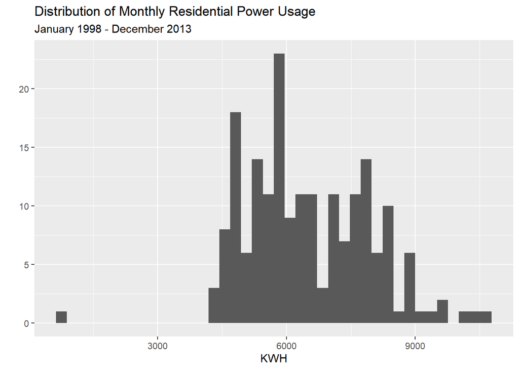

```r
#distro plot
ggplot(power_tsibble, aes(x=KWH))+
  geom_histogram(bins=40)+
  labs(title = "Distribution of Monthly Residential Power Usage",
       subtitle="January 1998 - December 2013") +
  ylab(label="")
```

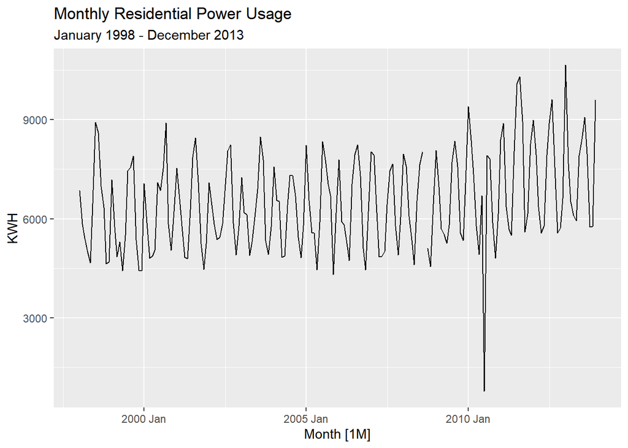

```r
#ts plot
power_tsibble %>%
  autoplot(KWH) +
  labs(title = "Monthly Residential Power Usage",
       subtitle="January 1998 - December 2013")
```

### Missing Values and Outliers

First a copy of the table is created, then the NA value is replaced using `na.interp`. Next, `tsoutliers` is used on the outlier identified above to detect and replace it. For some reason, the `tsoutliers` function didn’t detect the outlier seen in the distribution to the far left. Instead of using the function to replace the outlier, it will be manually replaced with the median in order not to further skew the distribution by changing it using the mean.

```r
#create a copy of the tsibble
power <- power_tsibble

#replace NA
power$KWH <- na.interp(power$KWH)

#find and detect outlier - didn't work
tsoutliers(power$KWH)
```

```
## $index
## integer(0)
##
## $replacements
## numeric(0)
```

```r
#manually change the outlier
power$KWH <- replace(power$KWH, power$KWH == min(power$KWH),
                          median(power$KWH))
```

Below is the distribution after resolving the NA value and the outlier, it still has a right skew. The time series plot of the variable shows strong seasonality with an upward trend picking up around 2008-2009. Given the skew of the data, a Box-Cox transformation might be useful.

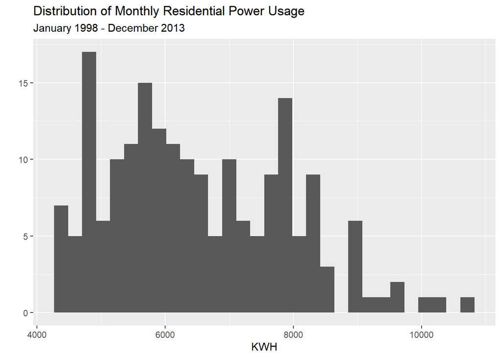

```r
#distro histo plot
ggplot(power, aes(x=KWH))+
  geom_histogram()+
  labs(title = "Distribution of Monthly Residential Power Usage",
       subtitle="January 1998 - December 2013") +
  ylab(label="")
```

```r
#summary
summary(power$KWH)
```

```
##    Min. 1st Qu.  Median    Mean 3rd Qu.    Max.
##    4313    5444    6330    6532    7609   10656
```

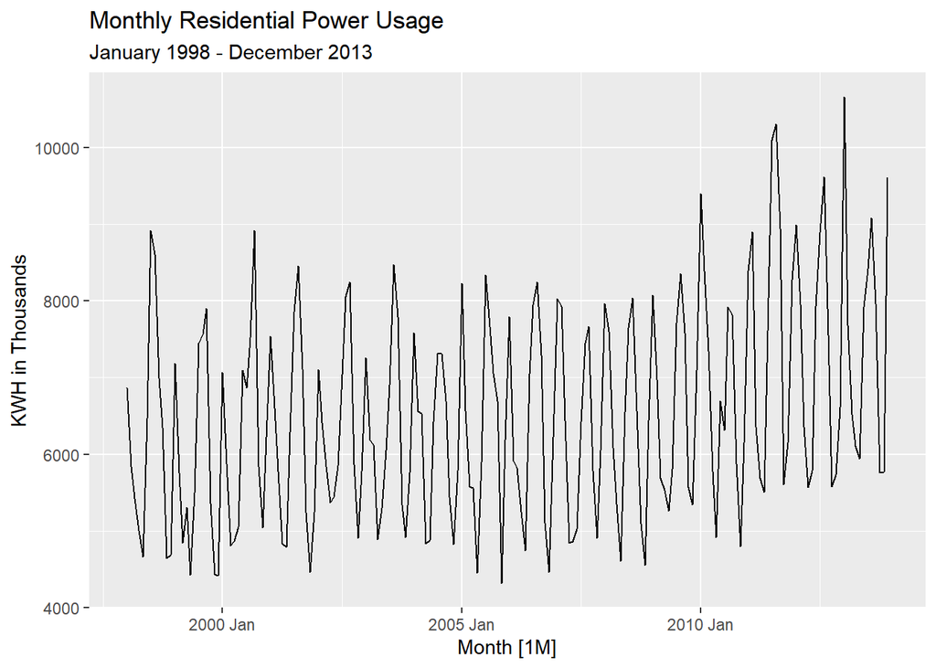

```r
#ts plot
power %>%
  autoplot(KWH) +
  labs(title = "Monthly Residential Power Usage",
       subtitle="January 1998 - December 2013")+
  ylab(label= "KWH in Thousands")
```

### Transformation

Below is the `summary()` for the Box-Cox transformed `power` data set which now has a normal distribution noted by the mean and median being equal; time series plot doesn’t look extremely different from the original time series plot besides the scale now being smaller and slightly less variance.

```r
#get lambda
lambda <- power %>%
  features(KWH, features = guerrero) %>%
  pull(lambda_guerrero)

#add new value
power <- power %>%
    mutate(KWH_bc = box_cox(KWH, lambda))

#stats
summary(power$KWH_bc)
```

```
##    Min. 1st Qu.  Median    Mean 3rd Qu.    Max.
##   3.905   3.943   3.967   3.967   3.994   4.043
```

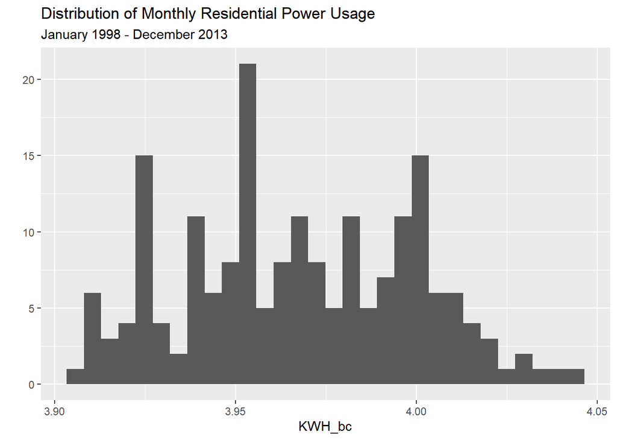

```r
#distro histo plot
ggplot(power, aes(x=KWH_bc))+
  geom_histogram()+
  labs(title = "Distribution of Monthly Residential Power Usage",
       subtitle="January 1998 - December 2013") +
  ylab(label="")
```

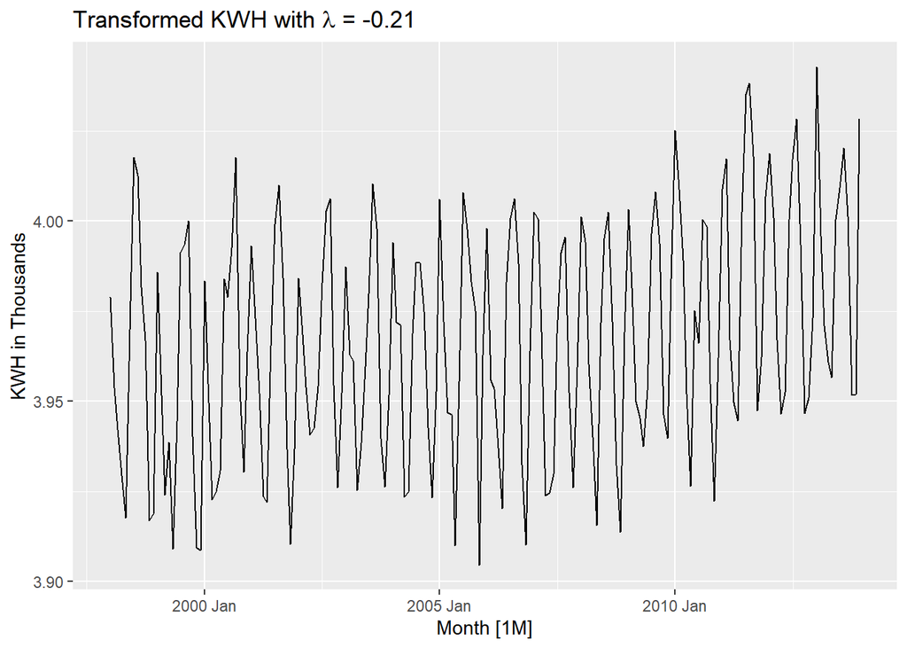

```r
#plot
power %>%
  autoplot(KWH_bc) +
  labs(y = "KWH in Thousands",
       title = latex2exp::TeX(paste0(
         "Transformed KWH with $\\lambda$ = ",
         round(lambda,2))))
```

### Forecast

To uncover additional patterns noted in the series, an STL “Seasonal and Trend decomposition using Loess” decomposition is performed given the seasonality of the series. Below we see the yearly seasonality and a trend appearing towards the end of the series.

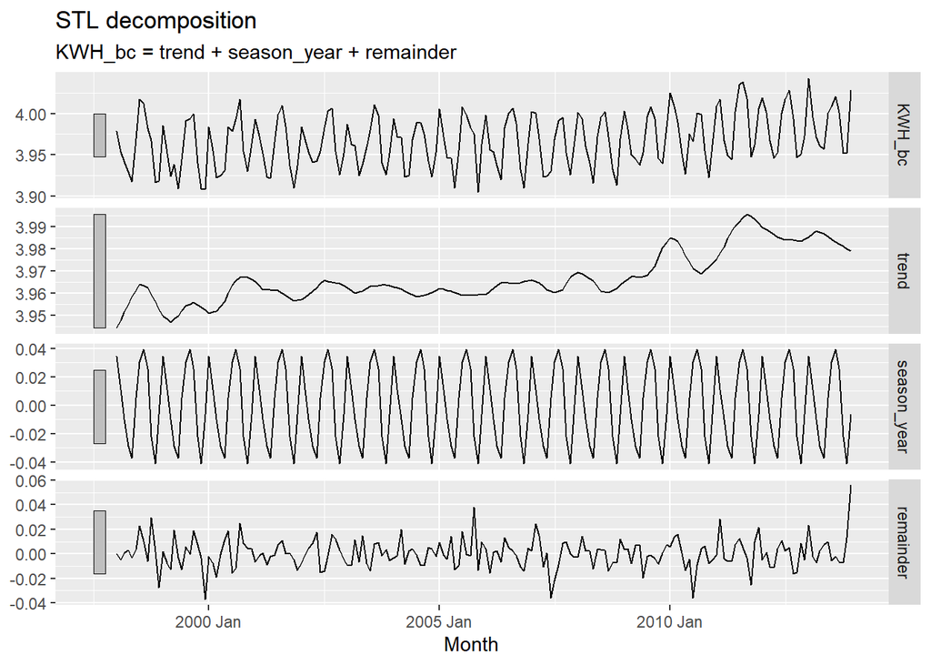

```r
power %>%
  model(
    STL(KWH_bc ~ trend(window = 13) +
                   season(window = "periodic"),
    robust = TRUE)) %>%
  components() %>%
  autoplot()
```

The ACF plot below tells us:

- $r_{12}$ is the highest of all the lags and is due to the seasonal pattern for the data. The highest lags are at every 12th r value.
- $r_{3}$ is the first highest negative lag and has a peak every 6 months onward (9,15,21,27,33). The troughs tend to be six months behind peaks.
- All of the correlations plotted are significantly different from zero as they all fall outside of the dashed blue lines.
- The 12 month lags appear to be decreasing relatively slowly which could be an indicator that the data is non-stationary and could potentially benefit from differencing. Additional check using `ndiffs()` will follow.

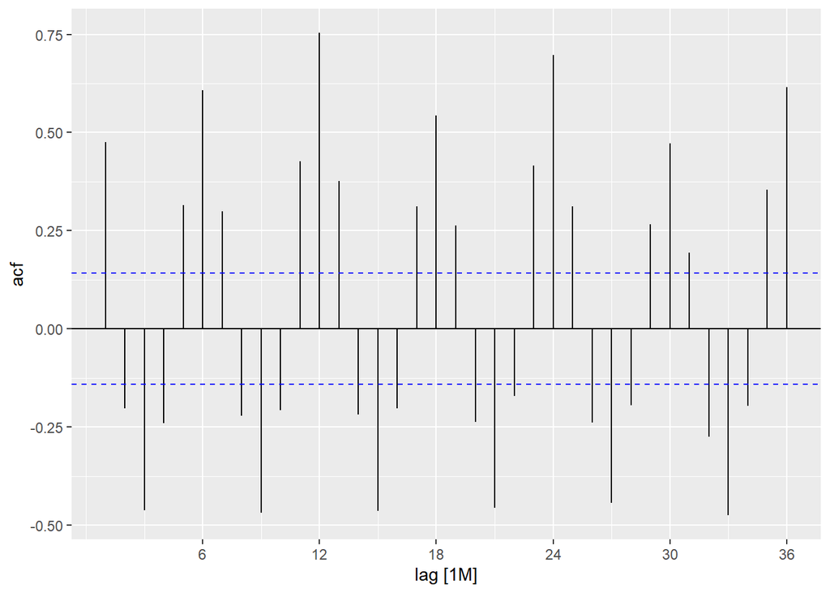

```r
power %>%
  ACF(KWH_bc, lag_max = 36) %>%
  autoplot()
```

```r
ndiffs(power$KWH_bc)
```

```
## [1] 1
```

```r
#need to add differenced data
diff_power <- power %>%
  mutate(diff_KWH= difference(KWH), diff_KWH_bc = difference(KWH_bc)) %>%
  #remove unecessary columns
  select(-KWH, -KWH_bc) %>%
  #first observation is NA due to differencing so remove
  slice(-1)

ndiffs(diff_power$diff_KWH_bc)
```

```
## [1] 0
```

### Model

Next the `diff_power` is split to create a training data set, `diff_train`. The power data is highly seasonal and resembles the high seasonality noted in the previous problem. As such, a similar approach will be taken in terms of running the same models, however use of a Holt’s-Winters’ additive ETS model has been included.

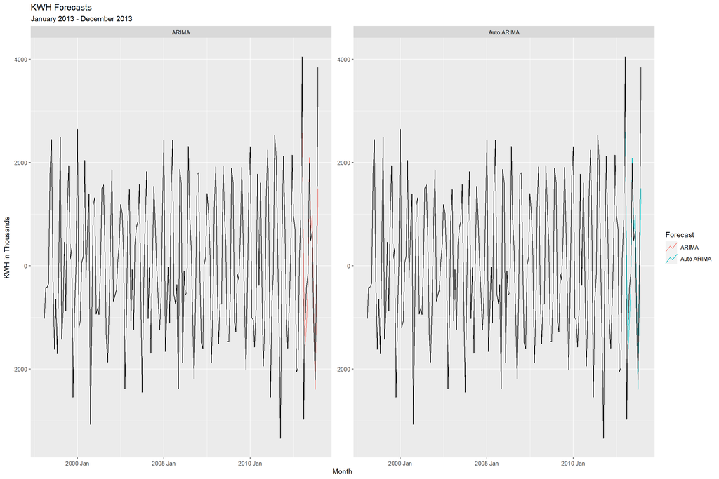

```r
#Differenced data for arima

#split
diff_train <- diff_power %>%
  filter(year(Month) < 2013)

#models
diff_fit <- diff_train %>%
    model(
    ARIMA = ARIMA(diff_KWH),
    `Auto ARIMA` = ARIMA(diff_KWH, stepwise = FALSE, approx = FALSE)
  )

#forecast of 2013
diff_fc <- diff_fit %>%
  forecast(h = "1 year")

#plot
diff_fc %>%
  autoplot(diff_power, level = NULL)+
  facet_wrap( ~ .model, scales = "free_y") +
  guides(colour = guide_legend(title = "Forecast"))+
  labs(title= "KWH Forecasts",
       subtitle = "January 2013 - December 2013")+
  xlab("Month") +
  ylab("KWH in Thousands")
```

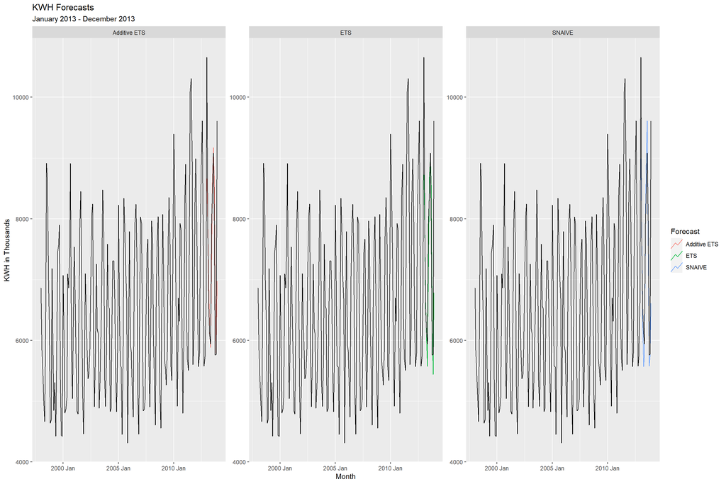

```r
#split
train <- power %>%
  filter(year(Month) < 2013)

#models
fit <- train %>%
    model(
    ETS = ETS(KWH),
    `Additive ETS` = ETS(KWH ~ error("A") + trend("A") + season("A")),
    SNAIVE = SNAIVE(KWH)
  )

#forecast of 2013
fc <- fit %>%
  forecast(h = "1 year")

#plot
fc %>%
  autoplot(power, level = NULL)+
  facet_wrap( ~ .model, scales = "free_y") +
  guides(colour = guide_legend(title = "Forecast"))+
  labs(title= "KWH Forecasts",
       subtitle = "January 2013 - December 2013")+
  xlab("Month") +
  ylab("KWH in Thousands")
```

### Evaluate

The `accuracy()` function is used to determine which model performed best based on their metrics. In review of the metrics, the Additive ETS model out performed all other models with lower RMSE with exception to the SNAIVE that has a the lowest MAE.

```r
#find ARIMA RMSE, MAE
accuracy(diff_fc, diff_power) %>%
  select(.model, RMSE:MAE)
```

```
## # A tibble: 2 x 3
##   .model      RMSE   MAE
##   <chr>      <dbl> <dbl>
## 1 ARIMA      1168.  774.
## 2 Auto ARIMA 1154.  771.
```

```r
#find other RMSE, MAE
accuracy(fc, power) %>%
  select(.model, RMSE:MAE)
```

```
## # A tibble: 3 x 3
##   .model        RMSE   MAE
##   <chr>        <dbl> <dbl>
## 1 Additive ETS 1020.  626.
## 2 ETS          1050.  664.
## 3 SNAIVE       1036.  619.
```

### Forecast

Finally the forecast values and plot are generated using the Additive ETS Forecast.

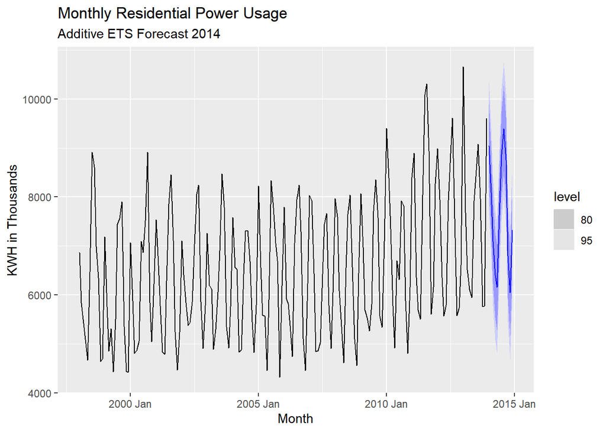

```r
#reproduce the mode using the original dataset
power_ETS_fit <- power %>%
  model(`Additive ETS` = ETS(KWH ~ error("A") + trend("A") + season("A")))

#generate the values
power_EST_forecast <- power_ETS_fit %>%
  forecast(h=12)

#plot
power_EST_forecast %>%
  autoplot(power) +
  labs(title = "Monthly Residential Power Usage",
       subtitle = "Additive ETS Forecast 2014",
       y = "KWH in Thousands")
```

Lastly, the values of the forecast are saved into .CSV format for submission.

```r
#convert to df and select only the columns needed
power_forecast_values <- as.data.frame(power_EST_forecast) %>%
  select(Month, .mean)

#fix column names
colnames(power_forecast_values) <- c('Month', 'KWH Forecast')

power_forecast_values
```

```
##       Month KWH Forecast
## 1  2014 Jan     9039.733
## 2  2014 Feb     8098.821
## 3  2014 Mar     7089.265
## 4  2014 Apr     6405.892
## 5  2014 May     6155.882
## 6  2014 Jun     7622.841
## 7  2014 Jul     8871.033
## 8  2014 Aug     9395.556
## 9  2014 Sep     8757.208
## 10 2014 Oct     6798.997
## 11 2014 Nov     6048.011
## 12 2014 Dec     7325.489
```

```r
#save to csv
write_excel_csv(power_forecast_values, "power_forecast.csv")
```

## References

[^1]: https://pkg.robjhyndman.com/forecast/reference/na.interp.html
[^2]: https://pkg.robjhyndman.com/forecast/reference/tsoutliers.html
[^3]: https://www.statisticshowto.com/kpss-test/#:~:text=What%20is%20the%20KPSS%20Test,variance%20%E2%80%94%20are%20constant%20over%20time.